# Report.1 In Class Starter (RMD Tricks)

March 01, 2022

# YAML

# Adjusting the set up chunk

**Remove** messages, warnings, and code.

# Heading Refresher

## Subheading

Fix the subheading above so it shows up correctly.

# Spacing

If you would like text on two lines make sure there are two spaces after.  
Like this.

# Aspect Ratio, Alignment, and Captions

Run the code below and look at the knitted version. Then add dpi= 250, fig.width=7, fig.height=7 to the code chunk header and knit again. Adding fig.cap with add a caption and fig.align can be changed to ‘center’, ‘left’ or ‘right’

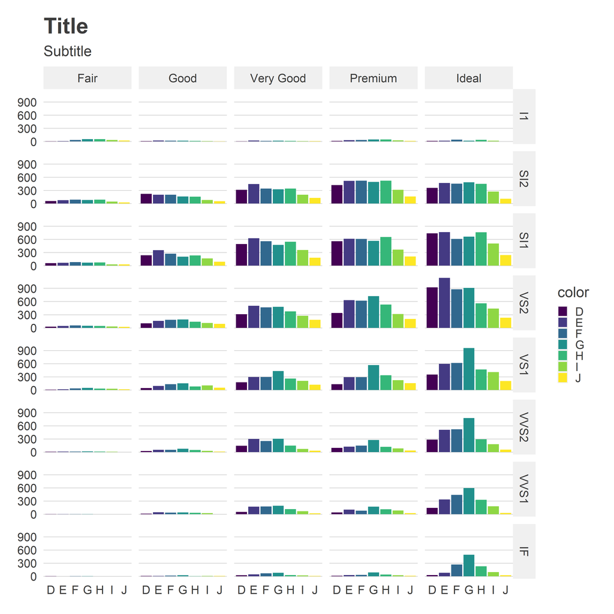

```r
diamonds %>%
      ggplot(aes(x = color, fill = color)) +
      geom_bar() +
      facet_grid(clarity ~ cut) +
      labs(title = "Title",
          subtitle = "Subtitle") +
      theme_new + theme(legend.position = "right",
                        legend.direction = "vertical",
                        legend.key.size = unit(.3, "cm"))
```

# Run all above and below.

Find these buttons and play with them.

# Visual Markdown Editor

Find this buttons and play with them.

# Knitting to doc versus html

# How to write good comments

Add comments to the following code chunk

```r
# Creating a new copy of the diamonds dataset
diamonds1 <- diamonds

# Creating a table
diamonds1 %>%
  filter(table >= 55) %>% # that shows just observations with a table of greater than 55
  group_by(color) %>%
  summarize(med_price = median(price)) %>% # And the median price for each color
  arrange(desc(med_price)) %>%
  head(5) # Only outputting the top 5
```

```
## # A tibble: 5 x 2
##   color med_price
##   <ord>     <dbl>
## 1 J         4347
## 2 I         3910.
## 3 H         3669
## 4 F         2372.
## 5 G         2352
```

```r
# Overwriting the table variable to be integers
diamonds1 <- diamonds1 %>% mutate(table = round(table))
```

# Tables

Take a look at the gross output of the code chunk above. We can use the pander package to make this a lot more appealing in our knitted file.

You will be outputting 1 summarization table in your knitted report.

# Inline code

Put the mean in the following text.

# Debugging

Uncomment the code below and try to debug it.

```r
# diamonds1 %>%
#   mutate(price_and_color = paste0("This diamond of color ", str_to_lower(color), " is $", format(round(price), big.mark = ",")
#          table = round(table)) %>% head() %>% pander()
```

The following tips may help:

1. Little red x
2. Rainbow parentheses
3. Stack overflow
4. eval = FALSE

# Projects

Create a dummy project.

```r
getwd()
```

```
## [1] "C:/Users/logan/OneDrive - Brigham Young University/Documents/MPA634/Class"
```

# RStudio Hygiene

1. Clean the global environment regularly
2. Restart whenever you have a new session. (OR when you have a code chunk that was working before but isn’t now!)
3. Create a new session if you are working on multiple different projects at the same time.

# Practice

How would I run this code in my markdown file but make sure it doesn’t output anything?

```r
summary(diamonds)
```

```
##      carat               cut        color        clarity          depth
##  Min.   :0.2000   Fair     : 1610   D: 6775   SI1    :13065   Min.   :43.00
##  1st Qu.:0.4000   Good     : 4906   E: 9797   VS2    :12258   1st Qu.:61.00
##  Median :0.7000   Very Good:12082   F: 9542   SI2    : 9194   Median :61.80
##  Mean   :0.7979   Premium  :13791   G:11292   VS1    : 8171   Mean   :61.75
##  3rd Qu.:1.0400   Ideal    :21551   H: 8304   VVS2   : 5066   3rd Qu.:62.50
##  Max.   :5.0100                     I: 5422   VVS1   : 3655   Max.   :79.00
##                                     J: 2808   (Other): 2531
##      table           price             x                y
##  Min.   :43.00   Min.   :  326   Min.   : 0.000   Min.   : 0.000
##  1st Qu.:56.00   1st Qu.:  950   1st Qu.: 4.710   1st Qu.: 4.720
##  Median :57.00   Median : 2401   Median : 5.700   Median : 5.710
##  Mean   :57.46   Mean   : 3933   Mean   : 5.731   Mean   : 5.735
##  3rd Qu.:59.00   3rd Qu.: 5324   3rd Qu.: 6.540   3rd Qu.: 6.540
##  Max.   :95.00   Max.   :18823   Max.   :10.740   Max.   :58.900
##
##        z
##  Min.   : 0.000
##  1st Qu.: 2.910
##  Median : 3.530
##  Mean   : 3.539
##  3rd Qu.: 4.040
##  Max.   :31.800
##
```

How would I keep it from running at all?

```r
summary(diamonds)
```

```
##      carat               cut        color        clarity          depth
##  Min.   :0.2000   Fair     : 1610   D: 6775   SI1    :13065   Min.   :43.00
##  1st Qu.:0.4000   Good     : 4906   E: 9797   VS2    :12258   1st Qu.:61.00
##  Median :0.7000   Very Good:12082   F: 9542   SI2    : 9194   Median :61.80
##  Mean   :0.7979   Premium  :13791   G:11292   VS1    : 8171   Mean   :61.75
##  3rd Qu.:1.0400   Ideal    :21551   H: 8304   VVS2   : 5066   3rd Qu.:62.50
##  Max.   :5.0100                     I: 5422   VVS1   : 3655   Max.   :79.00
##                                     J: 2808   (Other): 2531
##      table           price             x                y
##  Min.   :43.00   Min.   :  326   Min.   : 0.000   Min.   : 0.000
##  1st Qu.:56.00   1st Qu.:  950   1st Qu.: 4.710   1st Qu.: 4.720
##  Median :57.00   Median : 2401   Median : 5.700   Median : 5.710
##  Mean   :57.46   Mean   : 3933   Mean   : 5.731   Mean   : 5.735
##  3rd Qu.:59.00   3rd Qu.: 5324   3rd Qu.: 6.540   3rd Qu.: 6.540
##  Max.   :95.00   Max.   :18823   Max.   :10.740   Max.   :58.900
##
##        z
##  Min.   : 0.000
##  1st Qu.: 2.910
##  Median : 3.530
##  Mean   : 3.539
##  3rd Qu.: 4.040
##  Max.   :31.800
##
```

How would I run it but hide the code?

```r
summary(diamonds)
```

```
##      carat               cut        color        clarity          depth
##  Min.   :0.2000   Fair     : 1610   D: 6775   SI1    :13065   Min.   :43.00
##  1st Qu.:0.4000   Good     : 4906   E: 9797   VS2    :12258   1st Qu.:61.00
##  Median :0.7000   Very Good:12082   F: 9542   SI2    : 9194   Median :61.80
##  Mean   :0.7979   Premium  :13791   G:11292   VS1    : 8171   Mean   :61.75
##  3rd Qu.:1.0400   Ideal    :21551   H: 8304   VVS2   : 5066   3rd Qu.:62.50
##  Max.   :5.0100                     I: 5422   VVS1   : 3655   Max.   :79.00
##                                     J: 2808   (Other): 2531
##      table           price             x                y
##  Min.   :43.00   Min.   :  326   Min.   : 0.000   Min.   : 0.000
##  1st Qu.:56.00   1st Qu.:  950   1st Qu.: 4.710   1st Qu.: 4.720
##  Median :57.00   Median : 2401   Median : 5.700   Median : 5.710
##  Mean   :57.46   Mean   : 3933   Mean   : 5.731   Mean   : 5.735
##  3rd Qu.:59.00   3rd Qu.: 5324   3rd Qu.: 6.540   3rd Qu.: 6.540
##  Max.   :95.00   Max.   :18823   Max.   :10.740   Max.   :58.900
##
##        z
##  Min.   : 0.000
##  1st Qu.: 2.910
##  Median : 3.530
##  Mean   : 3.539
##  3rd Qu.: 4.040
##  Max.   :31.800
##
```

How would I hide any warnings that come in the code?

```r
summary(diamonds)
```

```
##      carat               cut        color        clarity          depth
##  Min.   :0.2000   Fair     : 1610   D: 6775   SI1    :13065   Min.   :43.00
##  1st Qu.:0.4000   Good     : 4906   E: 9797   VS2    :12258   1st Qu.:61.00
##  Median :0.7000   Very Good:12082   F: 9542   SI2    : 9194   Median :61.80
##  Mean   :0.7979   Premium  :13791   G:11292   VS1    : 8171   Mean   :61.75
##  3rd Qu.:1.0400   Ideal    :21551   H: 8304   VVS2   : 5066   3rd Qu.:62.50
##  Max.   :5.0100                     I: 5422   VVS1   : 3655   Max.   :79.00
##                                     J: 2808   (Other): 2531
##      table           price             x                y
##  Min.   :43.00   Min.   :  326   Min.   : 0.000   Min.   : 0.000
##  1st Qu.:56.00   1st Qu.:  950   1st Qu.: 4.710   1st Qu.: 4.720
##  Median :57.00   Median : 2401   Median : 5.700   Median : 5.710
##  Mean   :57.46   Mean   : 3933   Mean   : 5.731   Mean   : 5.735
##  3rd Qu.:59.00   3rd Qu.: 5324   3rd Qu.: 6.540   3rd Qu.: 6.540
##  Max.   :95.00   Max.   :18823   Max.   :10.740   Max.   :58.900
##
##        z
##  Min.   : 0.000
##  1st Qu.: 2.910
##  Median : 3.530
##  Mean   : 3.539
##  3rd Qu.: 4.040
##  Max.   :31.800
##
```